# 1920 Sem 2

BT1101 Student. Neo Haowei

19 Nov 2021, 1:00 - 3:30 PM

## Question List

### - Q1 : Statistical Measures, Probability distributions, Hypo testing

### - Q2 : Linear Regression

### - Q3 : Integer Optimization

## Preparation

```r
library('libcoin')
library("rcompanion") #this package is required for transformTukey function
library("rstatix")
library("Rmisc")
library("dplyr") #need to call the library before you use the package
library("tidyr")
library("rpivotTable")
library("knitr")
library("psych")
library(tidyverse)
library(ggplot2)
library(factoextra) # for fviz_cluster()
library(lpSolve)

# predictive/prescriptive analytics
library(tseries)
library(forecast)
library(lpSolve)
library(TTR)

# descriptive analytics
library(psych)
library(Rmisc)
library(rcompanion)
library(rpivotTable)
library(EnvStats)
library(car)
library(rstatix)

# general use
library(wooldridge)
library(dplyr)
library(tidyr)
library(knitr)
```

## Some Formulas:

Mean use T-test, Proportion Z-test  
test statistic z for proportion: (proportion-probability) / sqrt(probability * (1-probability)/n)  
test statistic t for comparing means: (new mean-old mean)/(sd/sqrt(n))  
z critical value: qnorm(0.05) # 5% level of significance, one tailed  
t critical value: qt(0.975,df=n-1)  
confidence interval for mean: mean +- `test statistic t` * (sd/sqrt(n)) OR use CI()  
prediction interval: mean +- `test statistic t` * (sd * sqrt(1+(1/n))  
confidence interval for proportions: p +- `test statistic z` * (sqrt(p*(1-p)/n))

## Question 1: CEO Salaries

Context: Use data(‘ceosal1’). This is a data set from a 1991 issue of Business Week of CEO’s salaries in 1990.

The data.frame has 209 observations on 12 variables:

- `salary`: 1990 salary, thousands $
- `pcsalary`: percent change salary, 1989-1990
- `sales`: 1990 firm sales, millions $
- `roe`: return on equity, 1988-1990 avg
- `pcroe`: percent change roe, 1988-1990
- `ros`: return on firm’s stock, 1988-1990
- `indus`: =1 if industrial firm
- `finance`: =1 if financial firm
- `consprod`: =1 if consumer product firm
- `utility`: =1 if transport or utilities
- `lsalary`: natural log of salary
- `lsales`: natural log of sales

Each observation represents a CEO’s salary with its respective firm characteristics. As a business analytics analyst, you are tasked to conduct the required analyses and present your findings according to the questions below.

```r
data('ceosal1')
CS<-ceosal1
```

#### Q1.(a) Plot a histogram for `salary`. What can you deduce about the distribution of CEO salaries from this histogram? (2 mark)

```r
summary(CS)
```

```
##      salary         pcsalary          sales              roe
##  Min.   :  223   Min.   :-61.00   Min.   :  175.2   Min.   : 0.50
##  1st Qu.:  736   1st Qu.: -1.00   1st Qu.: 2210.3   1st Qu.:12.40
##  Median : 1039   Median :  9.00   Median : 3705.2   Median :15.50
##  Mean   : 1281   Mean   : 13.28   Mean   : 6923.8   Mean   :17.18
##  3rd Qu.: 1407   3rd Qu.: 20.00   3rd Qu.: 7177.0   3rd Qu.:20.00
##  Max.   :14822   Max.   :212.00   Max.   :97649.9   Max.   :56.30
##      pcroe            ros            indus           finance
##  Min.   :-98.9   Min.   :-58.0   Min.   :0.0000   Min.   :0.0000
##  1st Qu.:-21.2   1st Qu.: 21.0   1st Qu.:0.0000   1st Qu.:0.0000
##  Median : -3.0   Median : 52.0   Median :0.0000   Median :0.0000
##  Mean   : 10.8   Mean   : 61.8   Mean   :0.3206   Mean   :0.2201
##  3rd Qu.: 19.5   3rd Qu.: 81.0   3rd Qu.:1.0000   3rd Qu.:0.0000
##  Max.   :977.0   Max.   :418.0   Max.   :1.0000   Max.   :1.0000
##     consprod         utility          lsalary          lsales
##  Min.   :0.0000   Min.   :0.0000   Min.   :5.407   Min.   : 5.166
##  1st Qu.:0.0000   1st Qu.:0.0000   1st Qu.:6.601   1st Qu.: 7.701
##  Median :0.0000   Median :0.0000   Median :6.946   Median : 8.217
##  Mean   :0.2871   Mean   :0.1722   Mean   :6.950   Mean   : 8.292
##  3rd Qu.:1.0000   3rd Qu.:0.0000   3rd Qu.:7.249   3rd Qu.: 8.879
##  Max.   :1.0000   Max.   :1.0000   Max.   :9.604   Max.   :11.489
```

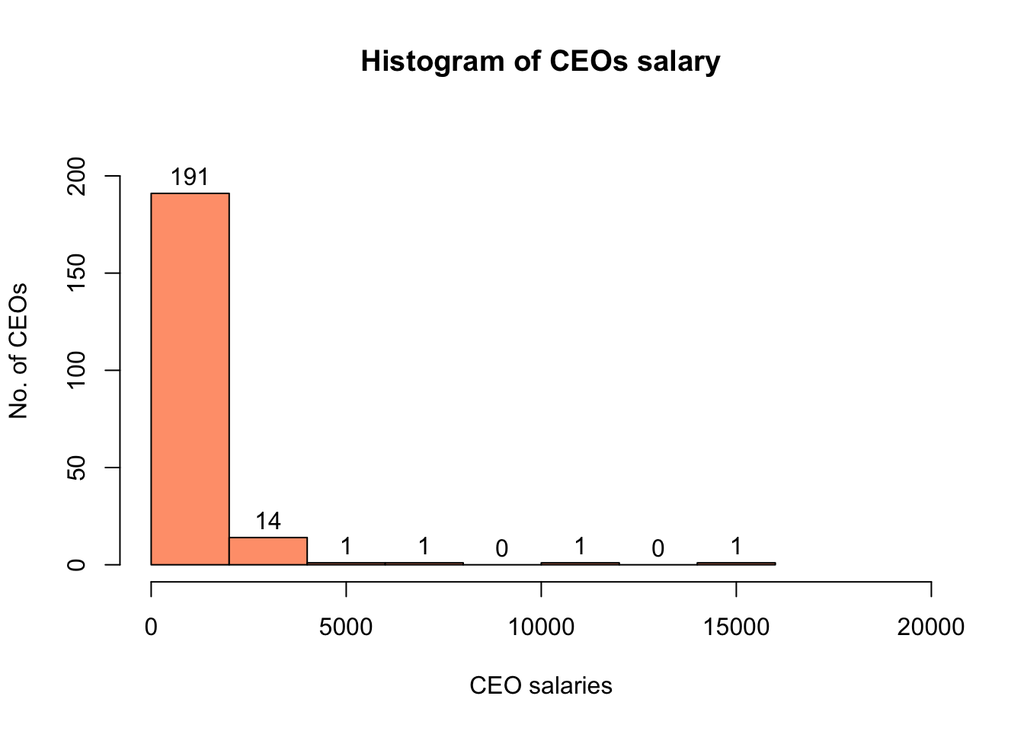

```r
salary.hist <- hist(CS$salary, main="Histogram of CEOs salary", xlab="CEO salaries", ylab="No. of CEOs", col=c("lightsalmon"), xlim=c(0,20000), ylim=c(0,220), labels=TRUE)
```

From this histogram, it does not look like a normal distribution as it does not follow a bell shape. Majority of the CEOs earn between $0 to $4,000 thousand range. Out of 209 CEOs, 205 CEOs earn between 0 to 4000 thousand. The distribution is right-skewed. There also seems to be 2 outliers earning between 10000 thousands to 16000 thousands from the histogram.

#### Q1.(b) In the past, the proportion of CEO with salary greater than $1 million has averaged around 0.50 (i.e. population proportion for `salary` >= 1million is 0.50). Based on the sample in this dataset, is there sufficient evidence (at 5% level of significance) to conclude that the population proportion for salary being greater than $1million is equal to 0.5? State your hypotheses, conduct the hypotheses test and provide conclusions. (5 marks)

```r
# 1,000,000 = 1,000 thousands

salmil <- CS %>% filter(salary>1000)
psalmil <- nrow(salmil)/nrow(CS)
z <- (psalmil - 0.50) / sqrt(0.50*(1-0.50)/nrow(CS)) # compute z-statistic for proportion
z
```

```
## [1] 0.622543
```

```r
lcv.salmil <- qnorm(0.05) # compute lower critical value
lcv.salmil
```

```
## [1] -1.644854
```

```r
ucv.salmil <- qnorm(0.95) # compute upper critical value
ucv.salmil
```

```
## [1] 1.644854
```

#### Q1.(c) You are tasked to explore if CEO salaries vary across firm types.

1. First, create a variable `firm` and label it as “1” if it is an industrial firm, “2” if it is a financial firm, “3” if it is a consumer product firm, and “4” if it is a transport or utilities firm. (1 mark)
2. Now, conduct the appropriate test(s) to assess if the mean CEO salary is significantly different across firm type. Present your hypotheses, the results and conclusions. (5 marks)

```r
#ci
CS<- CS %>% mutate(firm = ifelse(indus == 1, "1", ifelse(finance == 1, "2", ifelse(consprod == 1, "3","4"))))
#cii
wa.out <- CS %>% welch_anova_test(salary ~ firm)
gh.out <- games_howell_test(CS, salary ~ firm)
wa.out
```

```
## # A tibble: 1 × 7
##   .y.        n statistic   DFn   DFd           p method
## * <chr>  <int>     <dbl> <dbl> <dbl>       <dbl> <chr>
## 1 salary   209      12.3     3  106. 0.000000566 Welch ANOVA
```

```r
gh.out
```

```
## # A tibble: 6 × 8
##   .y.    group1 group2 estimate conf.low conf.high     p.adj p.adj.signif
## * <chr>  <chr>  <chr>     <dbl>    <dbl>     <dbl>     <dbl> <chr>
## 1 salary 1      2          206.    -226.      637. 0.593     ns
## 2 salary 1      3          583.    -202.     1368. 0.215     ns
## 3 salary 1      4         -411.    -645.     -178. 0.0000714 ****
## 4 salary 2      3          378.    -474.     1229. 0.653     ns
## 5 salary 2      4         -617.   -1035.     -199. 0.001     ***
## 6 salary 3      4         -994.   -1772.     -216. 0.007     **
```

H0: mean CEO salary is same across firms of the four different types.  
H1: at least one firm type has a different mean CEO salary from the other types of firms.  
Since p-value = 5.66e-07(<0.05), we have sufficient evidence to reject H0. We conclude at least one firm type has a different mean CEO salary from the other types of firms.  
From Games Howell test, pairs 1:4, pairs 2:4 and 3:4 are significantly different from the rest as their p-values are <0.05. Thus, I can conclude that the mean CEO salary for transport or utilities firms has a significantly different mean CEO salary from the rest of the firms.

## Question 2: Savings

This data set contains 100 observations with following variables: - `sav`: annual savings, $ - `inc`: annual income, $ - `size`: family size - `educ`: years education, household head - `age`: age of household head - `black`: =1 if household head is black - `cons`: annual consumption, $

```r
# load the data set, make sure you already load `wooldridge` package
data(saving)
SV <- saving
summary(SV)
```

```
##       sav               inc             size            educ
##  Min.   :-5577.0   Min.   :  750   Min.   : 2.00   Min.   : 2.00
##  1st Qu.:  194.5   1st Qu.: 6510   1st Qu.: 3.00   1st Qu.: 9.00
##  Median :  982.0   Median : 8776   Median : 4.00   Median :12.00
##  Mean   : 1582.5   Mean   : 9941   Mean   : 4.35   Mean   :11.58
##  3rd Qu.: 1834.8   3rd Qu.:11903   3rd Qu.: 5.00   3rd Qu.:13.00
##  Max.   :25405.0   Max.   :32080   Max.   :10.00   Max.   :20.00
##       age            black           cons
##  Min.   :26.00   Min.   :0.00   Min.   :-13055
##  1st Qu.:33.00   1st Qu.:0.00   1st Qu.:  5732
##  Median :38.50   Median :0.00   Median :  7562
##  Mean   :38.77   Mean   :0.07   Mean   :  8359
##  3rd Qu.:44.00   3rd Qu.:0.00   3rd Qu.:  9864
##  Max.   :54.00   Max.   :1.00   Max.   : 30280
```

#### Q2.(a) It is interesting to explain the individual saving sav from various explanatory variables.

• Run a linear regression model of sav ~ inc + cons, report the regression output and write out the fitted line. (2 points)  
• Interpret the intercept as well as the coefficients before inc and cons. (3 points)  
• Can we use sav, cons and inc altogether as explantory variables in linear regression? Why or why not? (2 points)

```r
fit1 = lm(sav ~ inc + cons, SV)
summary(fit1)
```

```
##
## Call:
## lm(formula = sav ~ inc + cons, data = SV)
##
## Residuals:
##        Min         1Q     Median         3Q        Max
## -4.702e-11  7.200e-14  2.510e-13  4.540e-13  2.172e-11
##
## Coefficients:
##               Estimate Std. Error    t value Pr(>|t|)
## (Intercept)  1.099e-11  1.106e-12  9.938e+00   <2e-16 ***
## inc          1.000e+00  1.748e-16  5.720e+15   <2e-16 ***
## cons        -1.000e+00  1.704e-16 -5.869e+15   <2e-16 ***
## ---
## Signif. codes:  0 '***' 0.001 '**' 0.01 '*' 0.05 '.' 0.1 ' ' 1
##
## Residual standard error: 5.393e-12 on 97 degrees of freedom
## Multiple R-squared:      1,  Adjusted R-squared:      1
## F-statistic: 1.837e+31 on 2 and 97 DF,  p-value: < 2.2e-16
```

The fitted line is savings = 1.099e-11 + 1 * inc - -1 * cons  
Intercept(b0) value = 1.099e-11, suggests average savings of a household with 0 income and with 0 consumption is 1.099e-11.  
Coefficient of `inc` = 1. Every unit increase of annual income is increases the average savings by 1 given all other predictors constant. The p-value=<2e-16 is very small,(< 0.05), thus we have sufficient evidence to reject the null hypothesis that the intercept is 0 and conclude that the slope parameter is statistically significant at the 5% level of confidence.  
Coefficient of `cons` = -1. Every unit increase of consumption decreases the average savings by 1 given all other predictors constant. The p-value=<2e-16 is very small,(< 0.05), thus we have sufficient evidence to reject the null hypothesis that the intercept is 0 and conclude that the slope parameter is statistically significant at the 5% level of confidence.

We cannot use them as explanatory variables. Multicollinearity occurs when two or more regressors are highly correlated with each other. In this case, inc - cons = saving. Thus, it is difficult to estimate the errors, which leads to inflated estimates of errors. Also, coefficient for inc and cons are merely definitions of annual income and annual consumption. They are not useful in determining relationships between saving and other regressors.

#### Q2.(b) Some labor economists believe that individual consumption is affected not only by income but by his or her education level nonlinearly as well. Let’s first create the following variable educsq which is equal to square of educ.

• Investigate the relationship between cons and inc visually. Is there a linear relationship between the two? (1 point) • Run and report a linear regression of inc, educ and educsq to explain cons. What’s the marginal effect of education on consumption for those individuals’ education level being 6 year? Interpret this marginal effect. (3 points)

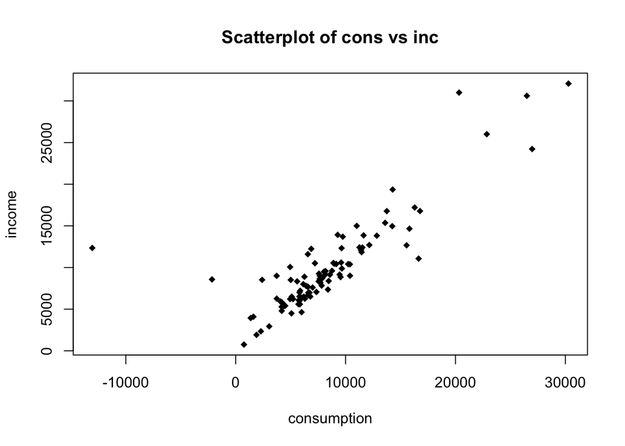

```r
# Create the following variable educsq which is equal to square of educ.
SV$educsq = SV$educ^2

# Scatterplot
plot(SV$cons, SV$inc, main="Scatterplot of cons vs inc", xlab="consumption", ylab="income", pch=18)
```

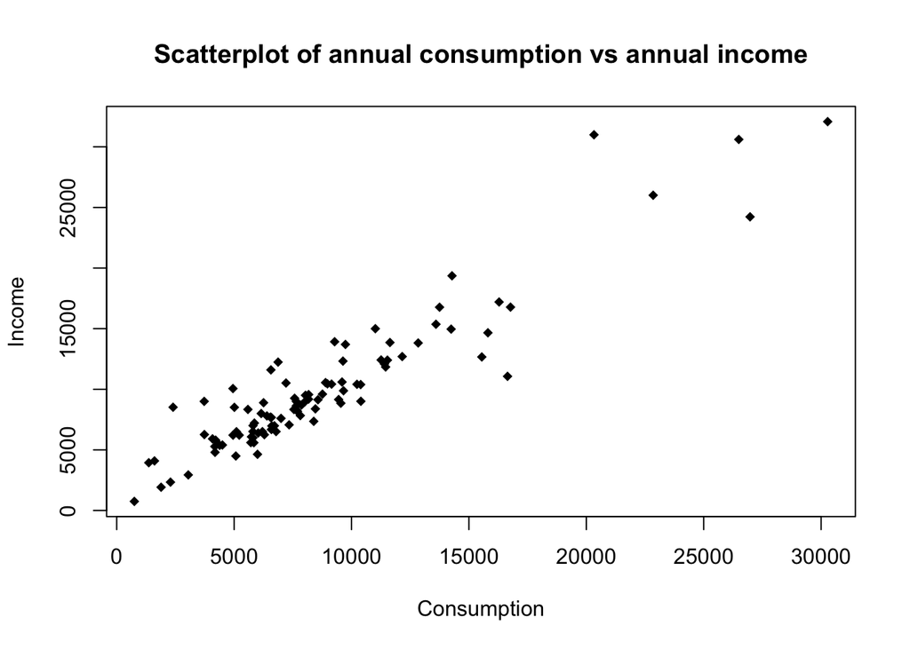

```r
#do not reject and take out these data as it is normal for a household to earn and spend more than other households due to different family size and lifestyle.
#however, take out these values where consumption is negative as it is impossible for consumption to be negative. These values might be recording error.

SV_clean <- SV %>% filter(cons >0)
# Scatterplot to check again
plot(SV_clean$cons,SV_clean$inc, main="Scatterplot of annual consumption vs annual income", xlab="Consumption", ylab="Income", pch=18)
```

```r
# Run and report a linear regression of inc, educ and educsq to explain cons
fit2 = lm(cons ~ inc + educ +educsq , SV_clean)
summary(fit2)
```

```
##
## Call:
## lm(formula = cons ~ inc + educ + educsq, data = SV_clean)
##
## Residuals:
##     Min      1Q  Median      3Q     Max
## -6612.9  -545.0   230.5   829.5  6940.3
##
## Coefficients:
##               Estimate Std. Error t value Pr(>|t|)
## (Intercept) -369.13415 1587.30170  -0.233    0.817
## inc            0.86492    0.03927  22.027   <2e-16 ***
## educ          74.34083  275.40075   0.270    0.788
## educsq        -2.71714   11.62854  -0.234    0.816
## ---
## Signif. codes:  0 '***' 0.001 '**' 0.01 '*' 0.05 '.' 0.1 ' ' 1
##
## Residual standard error: 1934 on 94 degrees of freedom
## Multiple R-squared:  0.8683, Adjusted R-squared:  0.8641
## F-statistic: 206.6 on 3 and 94 DF,  p-value: < 2.2e-16
```

Part 1 :  
From the scatterplot above, there is a linear relationship between income and consumption.  
Part 2:  
The marginal effect of education on consumption for those individuals’ education level is 74.34083 - 2 x 2.71714 x educ. When educ = 6, the marginal effect of education on consumption = 74.34083 - 2(2.71714(6)) = 41.73515.  
This means that when individuals’ education level is 6 years, average consumption will increase by 41.73515, ceteris paribus.

#### Q2.(c) From the regression output in part (b), - Is there a nonlinear relationship between education and consumption? Why or why not? (1 points) - Check the assumptions and discuss what you find. Which assumption(s) are you worry about? (3 points)

##### Not sure!

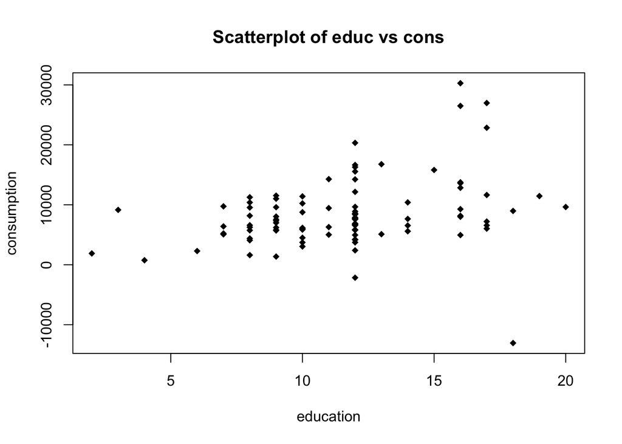

```r
plot(SV$educ, SV$cons, main="Scatterplot of educ vs cons", xlab="education", ylab="consumption", pch=18)
```

The data shows little evidence that there exists such non-linear relationship between education and consumption as educsq is statistically insignificant with p-value larger than the conventional cutoffs. (p-value = 0.816 > 0.05)  
Assumption:Linear relationship between DV and IV;No outliers;Normally-distributed errors  
There seems to be an outlier where consumption is -10000. I am concerned about this as it would skew a normal distribution. (resolved using clean dataset)

## Question 3: Linear Optimization

#### Q3(a) Write down your decision variables, the objective function, and ALL constraints that apply for this optimization problem in a table. You do not need to solve the problem for now. (5 points)

| Minimize total cost using decision variables $X_1$, $X_2$, $X_{11}$, $X_{12}$, $X_{21}$ | Cost = 499 $X_1$ + 450$X_2$ + 1099$X_{11}$ + 627$X_{12}$ + 100$X_{21}$ |
| --- | --- |
| Subject to |  |
| Motherboard CPU Constraint | $X_1$ + $X_2$ + $\quad$ + $\quad$ + $\quad$ = 1 |
| Motherboard GPU Constraint | $\quad$ + $\quad$ + $X_{11}$ + $X_{12}$ + $\quad$ $\leq$ 2 |
| Motherboard RAM Constraint | $\quad$ + $\quad$ + $\quad$ + $\quad$ + $X_{21}$ $\leq$ 4 |
| Motherboard RAM Constraint | $\quad$ + $\quad$ + $\quad$ + $\quad$ + $X_{21}$ $\geq$ 1 |
| Intel i9 Stock Constraint | $X_1$ + $\quad$ + $\quad$ + $\quad$ + $\quad$ $\leq$ 1 |
| AMD Ryzen Stock Constraint | $\quad$ + $X_2$ + $\quad$ + $\quad$ + $\quad$ $\leq$ 1 |
| Nvidia RTX 2080 Stock Constraint | $\quad$ + $\quad$ + $X_{11}$ + $\quad$ + $\quad$ $\leq$ 1 |
| AMD Radeon 56 Stock Constraint | $\quad$ + $\quad$ + $\quad$ + $X_{12}$ + $\quad$ $\leq$ 3 |
| 8G RAM card Stock Constraint | $\quad$ + $\quad$ + $\quad$ + $\quad$ + $X_{21}$ $\leq$ 8 |
| Performance Constraint | 20$X_1$ + 18$X_2$ + 90$X_{11}$ + 75$X_{12}$ + 10$X_{21}$ $\geq$ 144 |
| Integer, Non-negativity Constraints | $X_1$ to $X_{21}$ all integers and $\geq$ 0 |

#### Q3(b) Your trustworthy shop specialist strongly recommended if you choose to get the Nvidia RTX 2080 GPU, your PC needs at least 16GB of RAM.

• Write down the constraint in its math expression. (2 points)  
• As you decide to follow the specialist’s suggestion, solve this problem in R. Which part(s) should you purchase to assemble your gaming PC? How much do you spend on it? (4 points)

2080 GPU 16GB Ram Constraint | 0.5$x_{21}$ -$x_{11}$ $\geq$ 0 or 2$x_{21}$ -$x_{11}$ $\geq$ 0 ?

##### New table

| Minimize total cost using decision variables $X_1$, $X_2$, $X_{11}$, $X_{12}$, $X_{21}$ | Cost = 499 $X_1$ + 450$X_2$ + 1099$X_{11}$ + 627$X_{12}$ + 100$X_{21}$ |
| --- | --- |
| Subject to |  |
| Motherboard CPU Constraint | $X_1$ + $X_2$ + $\quad$ + $\quad$ + $\quad$ = 1 |
| Motherboard GPU Constraint | $\quad$ + $\quad$ + $X_{11}$ + $X_{12}$ + $\quad$ $\leq$ 2 |
| Motherboard RAM Constraint | $\quad$ + $\quad$ + $\quad$ + $\quad$ + $X_{21}$ $\leq$ 4 |
| Motherboard RAM Constraint | $\quad$ + $\quad$ + $\quad$ + $\quad$ + $X_{21}$ $\geq$ 1 |
| Intel i9 Stock Constraint | $X_1$ + $\quad$ + $\quad$ + $\quad$ + $\quad$ $\leq$ 1 |
| AMD Ryzen Stock Constraint | $\quad$ + $X_2$ + $\quad$ + $\quad$ + $\quad$ $\leq$ 1 |
| Nvidia RTX 2080 Stock Constraint | $\quad$ + $\quad$ + $X_{11}$ + $\quad$ + $\quad$ $\leq$ 1 |
| AMD Radeon 56 Stock Constraint | $\quad$ + $\quad$ + $\quad$ + $X_{12}$ + $\quad$ $\leq$ 3 |
| 8G RAM card Stock Constraint | $\quad$ + $\quad$ + $\quad$ + $\quad$ + $X_{21}$ $\leq$ 8 |
| Performance Constraint | 20$X_1$ + 18$X_2$ + 90$X_{11}$ + 75$X_{12}$ + 10$X_{21}$ $\geq$ 144 |
| 2080 GPU 16GB Ram Constraint | $\quad$ + $\quad$ -$X_{11}$ + $\quad$ + 0.5(or isit 2?)$X_{21}$ $\geq$ 0 |
| Integer, Non-negativity Constraints | $X_1$ to $X_{21}$ all integers and $\geq$ 0 |

```r
## integer optimisation
objective.fn <- c(499,450,1099,627,100)
const.mat = matrix(c(# Constraint 1: Motherboard constraint
                     rep(1,2),rep(0,3),
                     rep(0,2),rep(1,2),rep(0,1),
                     rep(0,4),rep(1,1),
                     rep(0,4),rep(1,1),
                     # Constraint 2: Stock constraint
                     1,0,0,0,0,
                     0,1,0,0,0,
                     0,0,1,0,0,
                     0,0,0,1,0,
                     0,0,0,0,1,
                     # Constraint 3: Performance constraint
                     20,18,90,75,10,
                     # Constraint 4: 2080 GPU 16GB Ram Constraint
                     0,0,-1,0,0.5
                     ), ncol = 5, byrow = TRUE)
const.dir = c('=', rep('<=', 2), '>=', rep('<=', 5), rep('>=', 2))
const.rhs = c(1,2,4,1,1,1,1,3,8,144,0)
# solving the linear problem
lp.solution = lp(direction = 'min', objective.fn,
              const.mat, const.dir, const.rhs,all.int = T, # all.int = T means all are integers
              compute.sens = TRUE)

lp.solution$solution
```

```
## [1] 0 1 0 2 1
```

```r
print(lp.solution)
```

```
## Success: the objective function is 1804
```

Minimum cost is $1804 , this could be achieved by purchasing one AMD Ryzen, 2 AMD Radeon 56 and 1 8G RAM card.

#### Q3(c) Now suppose that the price for Nvidia RTX 2080 GPU is uncertain, fluctuating ±55% uniformly based on the current price. You have a budget and thus can pay at most $1500 for your new PC. What’s the prbability that you are not able to get the PC you want at the moment?

Assuming you need to get RTX 2080

```r
## integer optimisation
objective.fn <- c(499,450,1099,627,100)
const.mat = matrix(c(# Constraint 1: Motherboard constraint
                     rep(1,2),rep(0,3),
                     rep(0,2),rep(1,2),rep(0,1),
                     rep(0,4),rep(1,1),
                     rep(0,4),rep(1,1),
                     # Constraint 2: Stock constraint
                     1,0,0,0,0,
                     0,1,0,0,0,
                     0,0,1,0,0,
                     0,0,0,1,0,
                     0,0,0,0,1,
                     # Constraint 3: Performance constraint
                     20,18,90,75,10,
                     # Constraint 4: 2080 GPU 16GB Ram Constraint
                     0,0,-1,0,0.5,
                     # Assuming you need to get RTX 2080
                     0,0,1,0,0
                     ), ncol = 5, byrow = TRUE)
const.dir = c('=', rep('<=', 2), '>=', rep('<=', 5), rep('>=', 2), '=')
const.rhs = c(1,2,4,1,1,1,1,3,8,144,0,1)
# solving the linear problem
lp.solution = lp(direction = 'min', objective.fn,
              const.mat, const.dir, const.rhs,all.int = T, # all.int = T means all are integers
              compute.sens = TRUE)

lp.solution$solution
```

```
## [1] 0 1 1 0 4
```

```r
print(lp.solution)
```

```
## Success: the objective function is 1949
```

```r
pnorm(650, 1099, 1099*0.55, lower.tail = FALSE)
```

```
## [1] 0.7712059
```